# DV_4_homework_CR

Christoph Rosa

2022-09-13

# Set-up

Installing packages:

```r
library(tidyverse)
```

Downloading and cleaning up data:

```r
tvratings <- read_csv("../Data/tv_ratings.csv")
glimpse(tvratings)
```

```
## Rows: 2,266
## Columns: 7
## $ titleId      <chr> "tt2879552", "tt3148266", "tt3148266", "tt3148266", "tt31…
## $ seasonNumber <dbl> 1, 1, 2, 3, 4, 1, 2, 1, 2, 3, 4, 5, 6, 7, 8, 1, 1, 1, 1, …
## $ title        <chr> "11.22.63", "12 Monkeys", "12 Monkeys", "12 Monkeys", "12…
## $ date         <date> 2016-03-10, 2015-02-27, 2016-05-30, 2017-05-19, 2018-06-…
## $ av_rating    <dbl> 8.4890, 8.3407, 8.8196, 9.0369, 9.1363, 8.4370, 7.5089, 8…
## $ share        <dbl> 0.51, 0.46, 0.25, 0.19, 0.38, 2.38, 2.19, 6.67, 7.13, 5.8…
## $ genres       <chr> "Drama,Mystery,Sci-Fi", "Adventure,Drama,Mystery", "Adven…
```

# Question 1

First, let’s filter out the “short” shows:

```r
tvlong <- tvratings %>%
  group_by(title) %>%
  mutate(num_seasons = max(seasonNumber)) %>%
  ungroup() %>%
  filter(num_seasons >= 5)
```

And now we plot their ratings over the course of their run:

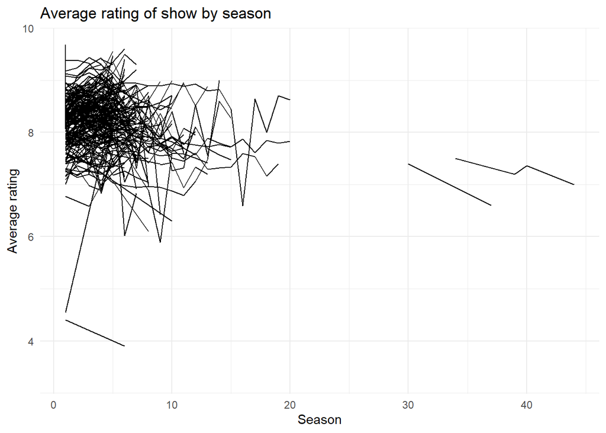

```r
ggplot(tvlong,
       aes(seasonNumber, av_rating,
           group = title)) +
  geom_line() +
  theme_minimal() +
  labs(title = "Average rating of show by season",
       x = "Season",
       y = "Average rating")
```

Honesty, I can’t.

# Question 2

Faceting by genre:

```
## geom_path: Each group consists of only one observation. Do you need to adjust
## the group aesthetic?
```

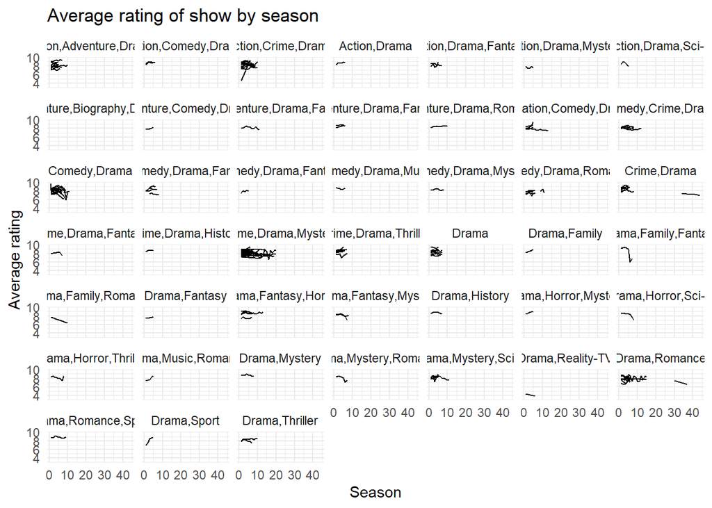

```r
ggplot(tvlong,
       aes(seasonNumber, av_rating,
           group = title)) +
  geom_line() +
  theme_minimal() +
    labs(title = "Average rating of show by season",
       x = "Season",
       y = "Average rating") +
  facet_wrap(~ genres)
```

```r
tvlong %>%
  filter(genres == "Drama,Family,Fantasy") %>%
  select(title, av_rating)
```

```
## # A tibble: 8 × 2
##   title                       av_rating
##   <chr>                           <dbl>
## 1 Are You Afraid of the Dark?      9.17
## 2 Are You Afraid of the Dark?      9.24
## 3 Are You Afraid of the Dark?      9.43
## 4 Are You Afraid of the Dark?      9.31
## 5 Are You Afraid of the Dark?      8.95
## 6 Are You Afraid of the Dark?      6.02
## 7 Are You Afraid of the Dark?      6.83
## 8 Touched by an Angel              9.6
```

Looks like “Are you Afraid of the Dark?” (whatever that is) really lost it in its last two seasons.

# Question 3

Plotting the best-rated shows:

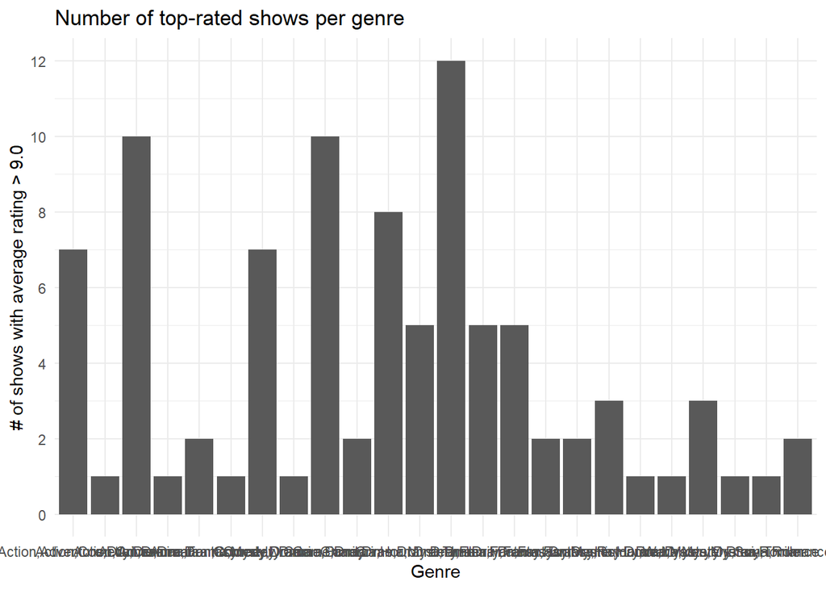

```r
best <- tvratings %>%
  filter(av_rating >= 9)

ggplot(best,
       aes(genres)) +
  geom_bar() +
  theme_minimal() +
  labs(title = "Number of top-rated shows per genre",
       x = "Genre",
       y = "# of shows with average rating > 9.0") +
  scale_y_continuous(breaks = seq(0, 14, 2))
```

Flipping the barplot:

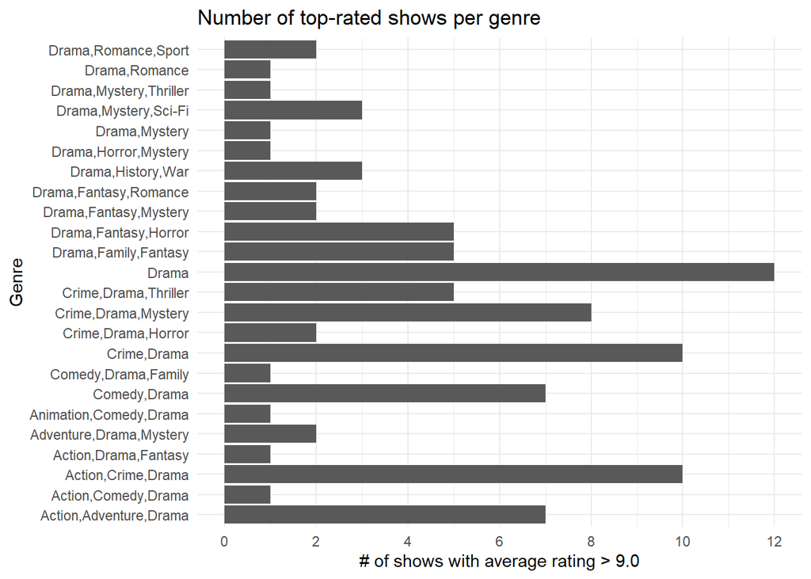

```r
ggplot(best,
       aes(genres)) +
  geom_bar() +
  theme_minimal() +
  labs(title = "Number of top-rated shows per genre",
       x = "Genre",
       y = "# of shows with average rating > 9.0") +
  scale_y_continuous(breaks = seq(0, 14, 2)) +
  coord_flip()
```

The genre drama has the most top-rated shows. Not very surprising since all the other genre-combinations are very specific.

# Question 4

Coding all comedy-somethings as comedies:

```r
comedies_dramas <- tvratings %>%
  mutate(is_comedy = if_else(str_detect(genres, "Comedy"),
                             1,
                             0)) %>% # If it contains the word comedy then 1, else 0
  filter(is_comedy == 1 | genres == "Drama") %>% # Keep comedies and dramas
  mutate(genres = if_else(genres == "Drama", # Make it so that we only have those two genres
                          "Drama",
                          "Comedy"))

glimpse(comedies_dramas)
```

```
## Rows: 684
## Columns: 8
## $ titleId      <chr> "tt0312081", "tt0312081", "tt0312081", "tt1225901", "tt12…
## $ seasonNumber <dbl> 1, 2, 3, 1, 2, 3, 4, 5, 1, 2, 1, 25, 1, 1, 2, 3, 4, 5, 1,…
## $ title        <chr> "8 Simple Rules", "8 Simple Rules", "8 Simple Rules", "90…
## $ date         <date> 2002-09-17, 2003-11-04, 2004-11-12, 2009-01-03, 2009-11-…
## $ av_rating    <dbl> 7.5000, 8.6000, 8.4043, 7.1735, 7.4686, 7.6858, 6.8344, 7…
## $ share        <dbl> 0.03, 0.10, 0.06, 0.40, 0.14, 0.10, 0.04, 0.01, 0.48, 0.4…
## $ genres       <chr> "Comedy", "Comedy", "Comedy", "Comedy", "Comedy", "Comedy…
## $ is_comedy    <dbl> 1, 1, 1, 1, 1, 1, 1, 1, 1, 1, 0, 1, 1, 1, 1, 1, 1, 1, 1, …
```

Comparing the two genres:

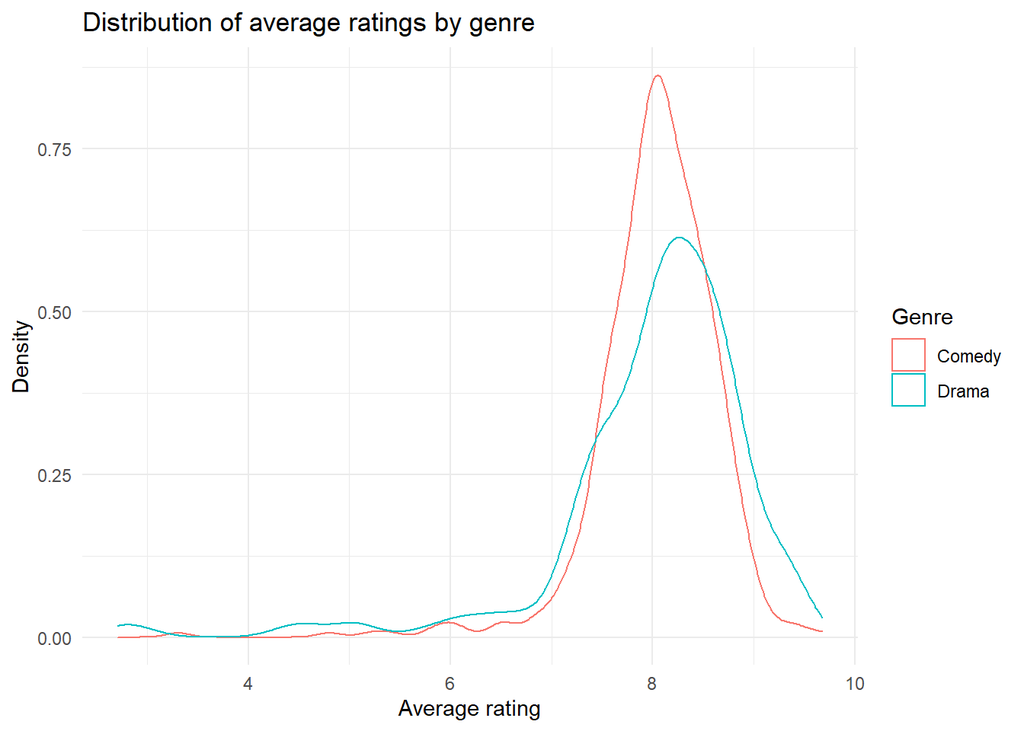

```r
ggplot(comedies_dramas,
       aes(av_rating, color = genres)) +
  geom_density() +
  theme_minimal() +
  labs(title = "Distribution of average ratings by genre",
       x = "Average rating",
       y = "Density",
       col = "Genre")
```

The densities are very similar, although dramas appear to be rated a tiny bit higher.

# Question 5

Plotting histograms:

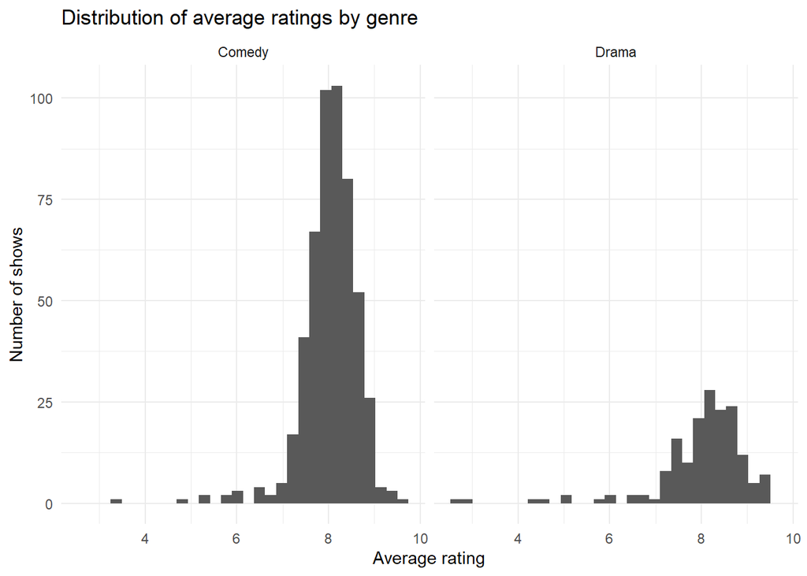

```r
ggplot(comedies_dramas,
       aes(av_rating)) +
  geom_histogram() +
  theme_minimal() +
  labs(title = "Distribution of average ratings by genre",
       x = "Average rating",
       y = "Number of shows") +
  facet_wrap(~ genres)
```

This shows that a) there were far more comedies (by our categorization) in the dataset and b) the distribution of low-rated outliers is quite similar.

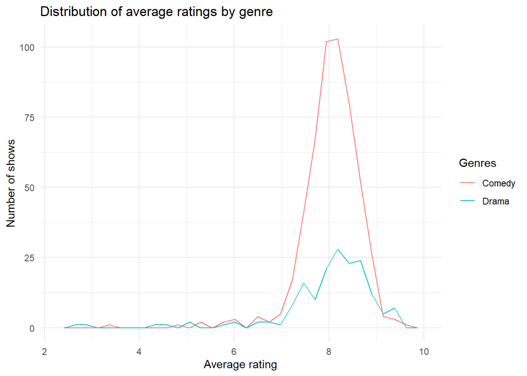

```r
ggplot(comedies_dramas,
       aes(av_rating, color = genres)) +
  geom_freqpoly() +
  theme_minimal() +
  labs(title = "Distribution of average ratings by genre",
       x = "Average rating",
       y = "Number of shows",
       col = "Genres")
```

For cases like this, I’d definitely prefer the frequency plot we plotted last.

# Question 6

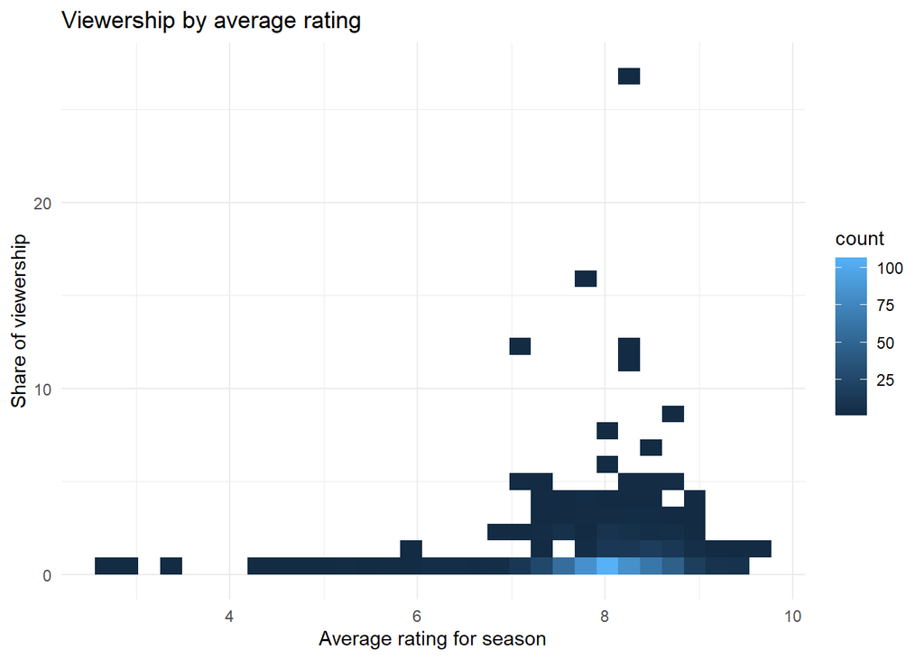

```r
ggplot(comedies_dramas,
       aes(av_rating, share)) +
  geom_bin_2d() +
  theme_minimal() +
  labs(title = "Viewership by average rating",
       x = "Average rating for season",
       y = "Share of viewership")
```

This creates a “heat map” which can be a bit more intuitive than a scatterplot when it comes to showing where the distribution is particularly dense.

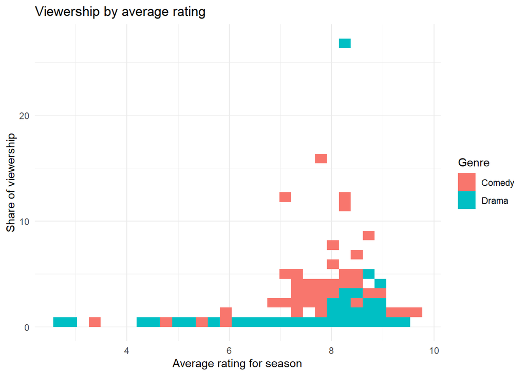

```r
ggplot(comedies_dramas,
       aes(av_rating, share,
           fill = genres)) +
  geom_bin_2d() +
  theme_minimal() +
  labs(title = "Viewership by average rating",
       x = "Average rating for season",
       y = "Share of viewership",
       fill = "Genre")
```

It looks as if decently-rated comedies had a much higher viewership than corresponding dramas.

```r
comedies_dramas$title[which.max(comedies_dramas$share)]
```

```
## [1] "Dekalog"
```

That was apparently “Dekalog”. Weird that I never heard of it, looks really interesting though.